{% raw %}

#### Baltimore Vital Signs

About the author: This notebook was forked from https://github.com/jtelszasz/baltimore_vital_signs. The original author is Justin Elszasz. You can follow Justin on Twitter [@TheTrainingSet](http://twitter.com/TheTrainingSet) or read his [blog](http://www.thetrainingset.com).

#### Imports

```python
import plotly.plotly as py
import plotly.graph_objs as pgo

import glob
import numpy as np
import pandas as pd
```

```python
# Load and combine the datasets.
path = 'raw_data/csv'

allFiles = glob.glob(path + '/*.csv')
df = pd.DataFrame()

for i, filename in enumerate(allFiles):
    df_file = pd.read_csv(filename)
    if i == 0:
        df = df_file
    else:
        df = pd.merge(df, df_file)

df.index = df['CSA2010']
df.drop('CSA2010', inplace=True)
print(len(df.columns))
del df['CSA2010']
print(len(df.columns))
```

```
296
295
```

```python
cols = df.columns
df[cols] = (
    df[cols]
    # Replace things that aren't numbers and change any empty entries to nan
    # (to allow type conversion)
    .replace({r'[^0-9\.]': '', '': np.nan}, regex=True)
    # Change to float and convert from %s
    .astype(np.float64)
)

# One of the rows is an aggregate Baltimore City.
df.drop('Baltimore City', inplace=True)
```

# A Few Exploratory Plots

Percentage of Population White in Each Neighborhood, Sorted

```python
df_white_sorted = df['pwhite10'].sort_values(inplace=False)

# Create a horizontal bar chart with plotly.
data = pgo.Data([
    pgo.Bar(
            y=df_white_sorted.index,
            x=df_white_sorted,
            orientation='h'
    )
])
```

```python
layout = pgo.Layout(
    title='% White',
    margin=pgo.Margin(l=300)  # add left margin for y-labels are long
)
```

```python
fig = pgo.Figure(data=data, layout=layout)
```

```python
py.iplot(fig, filename='baltimore-barh',
         width=700, height=1000)  # adjust notebook display width and height
```

[interactive chart not shown]

Percentage of Households in Poverty and with Children, Sorted

```python
df_chpov_sorted = df['hhchpov12'].sort_values(inplace=False)
```

```python
data1 = pgo.Data([
    pgo.Bar(
            y=df_chpov_sorted.index,
            x=df_chpov_sorted,
            orientation='h'
    )
])
```

```python
# Specify some layout attributes.
layout1 = pgo.Layout(
    title='% HH w. Children in Poverty',
    margin=pgo.Margin(l=300)  # add left margin for y-labels are long
)
```

```python
fig1 = pgo.Figure(data=data1, layout=layout1)
```

```python
py.iplot(fig1, filename='baltimore-hh-pov', width=700, height=1000)
```

[interactive chart not shown]

Percentage Households in Poverty with Children vs  
Percentage Population White (per Neighborhood)

```python
# Juvenile population (age 10 to 18)
juv_pop = df['tpop10'] * df['age18_10'] / 100
```

```python
# Display this information in hover box.
hover_text = list(zip(juv_pop.index, np.around(juv_pop, 2)))
```

```python
# Represent a third dimension (size).
data2 = pgo.Data([
    pgo.Scatter(
            x=df['pwhite10'],
            y=df['hhchpov12'],
            mode='markers',
            marker=pgo.Marker(size=juv_pop,
                              sizemode='area',
                              sizeref=juv_pop.max()/600,
                              opacity=0.4,
                              color='blue'),
            text=hover_text
    )
])
```

```python
layout2 = pgo.Layout(
    title='Baltimore: Too Many Non-White Kids in Poverty',
    xaxis=pgo.XAxis(title='% Population White (2010)',
                    range=[-5, 100],
                    showgrid=False,
                    zeroline=False),
    yaxis=pgo.YAxis(title='% HH w. Children in Poverty (2012)',
                    range=[-5, 100],
                    showgrid=False,
                    zeroline = False),
    hovermode='closest'
)
```

```python
fig2 = pgo.Figure(data=data2, layout=layout2)
```

```python
py.iplot(fig2, filename='baltimore-bubble-chart')
```

[interactive chart not shown]

Percentage of Households in Poverty  
vs Ethnicity's Percentage of Population  
Let's do this chart using matplotlib for a change.

```python
import matplotlib.pyplot as plt
```

```
Text(0.5,0,'% Population')
```

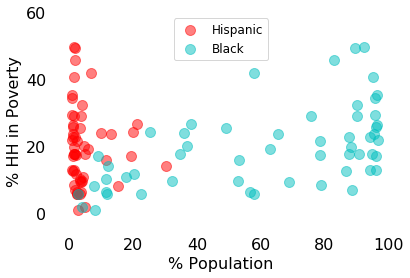

```python
mpl_fig, ax = plt.subplots()

size = 100
alpha = 0.5
fontsize = 16

ax.scatter(df['phisp10'], df['hhpov12'], c='r', alpha=alpha, s=size)
ax.scatter(df['paa10'], df['hhpov12'], c='c', alpha=alpha, s=size)
ax.legend(['Hispanic', 'Black'], fontsize=12)

# Turn off square border around plot.
ax.spines['top'].set_visible(False)
ax.spines['right'].set_visible(False)
ax.spines['bottom'].set_visible(False)
ax.spines['left'].set_visible(False)

# Turn off ticks.
ax.tick_params(axis="both", which="both", bottom="off", top="off",
               labelbottom="on", left="off", right="off", labelleft="on",
               labelsize=16)

ax.set_ylim(-5, 60)
ax.set_xlim(-5, 100)

ax.set_ylabel('% HH in Poverty', fontsize=fontsize)
ax.set_xlabel('% Population', fontsize=fontsize)
```

Matplotlib code is very long... But sometimes you have existing matplotlib code, right? The good news is, plotly can eat it!

```python
py.iplot_mpl(mpl_fig, filename='baltimore-poverty-bad-legend')
```

[interactive chart not shown]

So, at the moment, matplotlib legends do not fully convert to plotly legends (please refer to our [user guide](https://plot.ly/python/matplotlib-to-plotly-tutorial/#Careful,-matplotlib-is-not-perfect-%28yet%29)). Let's tweak this now.

```python
import plotly.tools as tls
```

```python
# Convert mpl fig object to plotly fig object, resize to plotly's default.
py_fig = tls.mpl_to_plotly(mpl_fig, resize=True)
```

```python
# Give each trace a name to appear in legend.
py_fig['data'][0]['name'] = py_fig['layout']['annotations'][0]['text']
py_fig['data'][1]['name'] = py_fig['layout']['annotations'][1]['text']
```

```python
# Delete misplaced legend annotations.
py_fig['layout'].pop('annotations', None)
```

```
[{'text': 'Hispanic',
  'opacity': 1,
  'x': 0.474584938212165,
  'y': 0.9061667037959644,
  'xref': 'paper',
  'yref': 'paper',
  'align': 'left',
  'xanchor': 'left',
  'yanchor': 'bottom',
  'showarrow': False,
  'font': {'color': '#000000', 'size': 12.0}},
 {'text': 'Black',
  'opacity': 1,
  'x': 0.474584938212165,
  'y': 0.8186099128474121,
  'xref': 'paper',
  'yref': 'paper',
  'align': 'left',
  'xanchor': 'left',
  'yanchor': 'bottom',
  'showarrow': False,
  'font': {'color': '#000000', 'size': 12.0}}]
```

```python
# Add legend, place it at the top right corner of the plot.
py_fig['layout'].update(
    showlegend=True,
    legend=pgo.Legend(
        x=1,
        y=1
    )
)
```

```python
# Send updated figure object to Plotly, show result in notebook.
py.iplot(py_fig, filename='baltimore-poverty')
```

[interactive chart not shown]

Hispanic communities are smaller fractions of neighborhood populations.

# Principal Component Analysis

Read this [post](http://www.thetrainingset.com/articles/A-City-Divided-In-N-Dimensions) at The Training Set for purpose of the following analyses (this section and the next one).

```python
from sklearn.decomposition import PCA
from sklearn.preprocessing import StandardScaler
```

```python
X = np.array(df)
scaler = StandardScaler()
X_scaled = scaler.fit_transform(X)
```

```python
pca = PCA()
pca.fit(X_scaled)
```

```
PCA(copy=True, iterated_power='auto', n_components=None, random_state=None,
  svd_solver='auto', tol=0.0, whiten=False)
```

```python
len(pca.components_)
```

```
55
```

55 dimensions (or components, or axes) were used in the Principal Component Analysis.

```python
print('Explained Variance Ratio = ', sum(pca.explained_variance_ratio_[: 2]))
```

```
Explained Variance Ratio =  0.48393732890888563
```

We can see that almost half (~48%) of the total variance comes from only two dimensions (i.e., the first two principal components). Let's visualize the relative contribution of all components.

```python
data3 = pgo.Data([
    pgo.Bar(
            y=pca.explained_variance_ratio_,
    )
])
```

```python
py.iplot(data3, filename="baltimore-principal-dimensions")
```

[interactive chart not shown]

Let's plot a cumulative version of this, to see how many dimensions are needed to account for 90% of the total variance.

```python
data4 = pgo.Data([
    pgo.Scatter(
            y=np.cumsum(pca.explained_variance_ratio_),
    )
])
```

```python
py.iplot(data4, filename='baltimore-pca-cumulative')
```

[interactive chart not shown]

So we need about 20 dimensions to explain ~90% of the total variance.

Let's focus on the 2 principal dimensions, so it's easy to plot them in the (x, y) plane.

```python
pca.n_components = 2
X_reduced = pca.fit_transform(X_scaled)
df_X_reduced = pd.DataFrame(X_reduced, index=df.index)
```

```python
trace = pgo.Scatter(x=df_X_reduced[0],
                    y=df_X_reduced[1],
                    text=df.index,
                    mode='markers',
                    # Size by total population of each neighborhood.
                    marker=pgo.Marker(size=df['tpop10'],
                                      sizemode='diameter',
                                      sizeref=df['tpop10'].max()/50,
                                      opacity=0.5)
)

data5 = pgo.Data([trace])
```

```python
layout5 = pgo.Layout(title='Baltimore Vital Signs (PCA)',
                     xaxis=pgo.XAxis(showgrid=False,
                                     zeroline=False,
                                     showticklabels=False),
                     yaxis=pgo.YAxis(showgrid=False,
                                     zeroline=False,
                                     showticklabels=False),
                     hovermode='closest'
)
```

```python
fig5 = pgo.Figure(data=data5, layout=layout5)
py.iplot(fig5, filename='baltimore-2dim')
```

[interactive chart not shown]

We have reduced a high-dimensional problem to a simple model. We can visualize it in 2 dimensions. Neighborhoods which lie closer to one another are more similar (with respect to these 'vital signs', i.e., socio-economic indicators). Downtown seems very special!

# K-means Clustering

Could we identify groups of similar neighborhoods? Clearly, Downtown forms its own group. It's not as easy to identify visually the other groups (or clusters). K-means clustering is an algorithmic method to compute closer data points (belonging to the same cluster), given the number of clusters you want.

```python
from sklearn.cluster import KMeans
```

The total number of clusters you expect should be small enough (otherwise there's no *clustering*) but large enough so that *inertia* can be reasonable (small enough). Inertia measures the typical distance between a data point and the center of its cluster.

```python
# Let the number of clusters be a parameter, so we can get a feel for an appropriate
# value thereof.
def cluster(n_clusters):
    kmeans = KMeans(n_clusters=n_clusters)
    kmeans.fit(X_reduced)
    Z = kmeans.predict(X_reduced)
    return kmeans, Z
```

```python
max_clusters = len(df)
# n_clusters = max_clusters would be trivial clustering.
```

```python
inertias = np.zeros(max_clusters)

for i in range(1, max_clusters):
    kmeans, Z = cluster(i)
    inertias[i] = kmeans.inertia_
```

```python
data6 = pgo.Data([
    pgo.Scatter(
            x=list(range(1, max_clusters)),
            y=inertias[1:]
    )
])
```

```python
layout6 = pgo.Layout(
    title='Baltimore dataset - Investigate k-means clustering',
    xaxis=pgo.XAxis(title='Number of clusters',
                    range=[0, max_clusters]),
    yaxis=pgo.YAxis(title='Inertia')
)
```

```python
fig6 = pgo.Figure(data=data6, layout=layout6)
```

```python
py.iplot(fig6, filename='baltimore-clustering-inertias')
```

[interactive chart not shown]

Okay, let's go for 7 clusters.

```python
n_clusters = 7
model, Z = cluster(n_clusters)
```

```python
# Represent neighborhoods as in previous bubble chart, adding cluster information under color.
trace0 = pgo.Scatter(x=df_X_reduced[0],
                     y=df_X_reduced[1],
                     text=df.index,
                     name='',
                     mode='markers',
                     marker=pgo.Marker(size=df['tpop10'],
                                       sizemode='diameter',
                                       sizeref=df['tpop10'].max()/50,
                                       opacity=0.5,
                                       color=Z),
                     showlegend=False
)
```

```python
# Represent cluster centers.
trace1 = pgo.Scatter(x=model.cluster_centers_[:, 0],
                     y=model.cluster_centers_[:, 1],
                     name='',
                     mode='markers',
                     marker=pgo.Marker(symbol='x',
                                       size=12,
                                       color=list(range(n_clusters))),
                     showlegend=False
)
data7 = pgo.Data([trace0, trace1])
layout7 = layout5
layout7['title'] = 'Baltimore Vital Signs (PCA and k-means clustering with 7 clusters)'
fig7 = pgo.Figure(data=data7, layout=layout7)
```

```python
py.iplot(fig7, filename='baltimore-cluster-map')
```

[interactive chart not shown]

Zoom, pan, and hover to explore this reduction of the Baltimore Vital Signs dataset!

{% endraw %}